# Utterance-final or in Australian English

Martin Schweinberger and Michael Haugh

Feb. 28, 2023

# Preparation

In a first step, we load or activate the packages.

```r
library(dplyr)
library(stringr)
library(tidyr)
library(quanteda)
library(here)
library(openxlsx)
library(knitr)
```

# Step 1: Computational extraction of all potential instances of utterance-final *or*

This section extracts potential instances or candidate examples of utterance-final *or* (UF-or) from four spoken corpora:

- [Australian Radio Talkback](https://www.ausnc.org.au/corpora/art)
- [Griffith Corpus of Spoken Australian English](https://www.ausnc.org.au/corpora/gcsause)
- [Monash corpus](https://www.ausnc.org.au/corpora/monash)
- [The La Trobe Corpus of Spoken Australian English](https://www.ausnc.org.au/corpora/latrobecsause)

## Loading data

The corpora were downloaded and stored in a directory (folder) called `data`. To load the data, we define the paths to the files containing the transcripts (which are located in the `data` folder in the specific sub-directories for the corpora).

> **NOTE**: DO NOT EXECUTE THE CODE CHUNKS BELOW! IT IS DISPLAYED FOR TRANSPARENCY REASONS ONLY! THE DATA IS NOT MADE AVAILABLE FOR COPYRIGHT REASONS!

> **THE INTERACTIVE CODE (CODE THAT IS EXECUTABLE) STARTS WITH THE SECTION “INTERACTIVE CODE BELOW”**

```r
fart <- list.files(here::here("data", "Australian Radio Talkback/files/Raw"), full.names = T)
fgri <- list.files(here::here("data", "Griffith Corpus of Spoken Australian English/files/Raw"),
                        pattern = ".txt", full.names = T)
fmon <- list.files(here::here("data", "Monash/files/Text"),
                        pattern = ".txt", full.names = T)
flat <- list.files(here::here("data", "The La Trobe Corpus of Spoken Australian English/files/Raw"),
                        pattern = ".txt", full.names = T)
```

We now check if we have the paths to the data by inspecting the first six paths of files in the *Australian Radio Talkback* corpus.

```r
# inspect
head(fart)
```

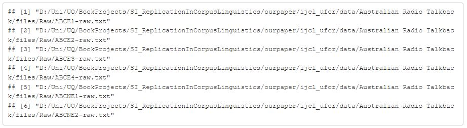

We now proceed by loading and processing (cleaning) the data.

### Load ART

We start with the content of the *Australian Radio Talkback* corpus (art).

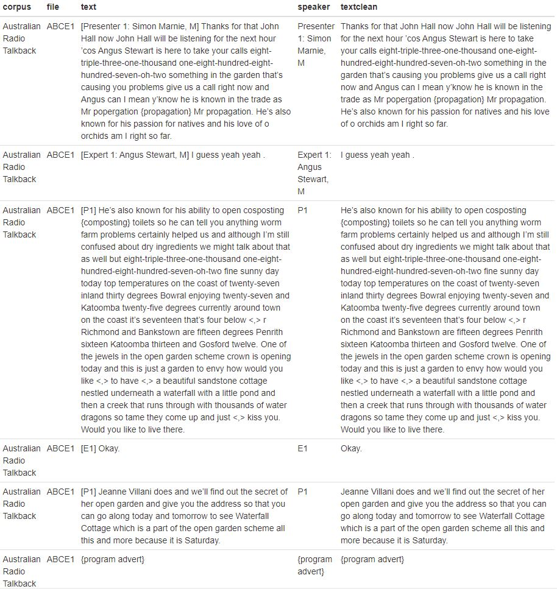

```r
# load raw content
vart <- sapply(fart, function(x){
  # read in content of the file
  x <- readLines(x)
  # remove empty rows
  x <- x[x != ""]
  })
# unlist the object containing the corpus data
arttext <- unlist(vart)
# collapse into a data frame
artdf <- data.frame(names(arttext), names(arttext),arttext) %>%
  # rename columns
  dplyr::rename(corpus = colnames(.)[1],
                file = colnames(.)[2],
                text = colnames(.)[3]) %>%
  # create new columns containing corpus, file, and speaker information as well as a column with clean content
  dplyr::mutate(
    # extract corpus name
    corpus = stringr::str_replace_all(corpus, ".*data/(.*?)/.*", "\\1"),
    # extract file name
    file = stringr::str_replace_all(file, ".*Raw/(.*?)-raw.*", "\\1"),
    # extract speaker
    speaker = stringr::str_replace_all(text, "\\[(.*?)\\].*", "\\1"),
    # clean transcripts
    textclean = stringr::str_remove_all(text, ".*?\\]"),
    # remove superfluous white spaces
    textclean = stringr::str_squish(textclean))
# remove row names
rownames(artdf) <- NULL
# inspect
knitr::kable(head(artdf))
```

### Load GRI

We continue with the content of the files of the *Griffith Corpus of Spoken Australian English* (gri).

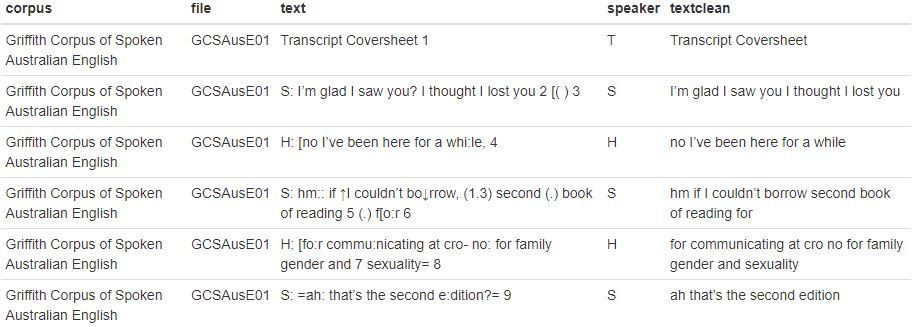

```r
vgri <- sapply(fgri, function(x){
  x <- readLines(x, encoding = "UTF-8")
  x <- x[x != ""]
  x <- x[!stringr::str_detect(x, "\\|.*\\|")]
  x <- paste0(x, collapse = " ")
  x <- stringr::str_split(stringr::str_replace_all(x, "( [A-Z]:)", "qwertz\\1"), "qwertz")
  x <- unlist(x)
  x <- stringr::str_squish(x)
})
gritext <- unlist(vgri)
# collapse into df
gridf <- data.frame(names(gritext), names(gritext),gritext) %>%
  dplyr::rename(corpus = colnames(.)[1],
                file = colnames(.)[2],
                text = colnames(.)[3]) %>%
  dplyr::mutate(corpus = stringr::str_replace_all(corpus, ".*data/(.*?)/.*", "\\1"),
                file = stringr::str_replace_all(file, ".*Raw/(.*?)-raw.*", "\\1"),
                speaker = stringr::str_remove_all(text, ":.*"),
                speaker = stringr::str_remove_all(speaker, "\\W.*\\W"),
                speaker = stringr::str_remove_all(speaker, "[^[:alpha:]]"),
                speaker = stringr::str_remove_all(speaker, "[a-z]"),
                textclean = stringr::str_remove_all(text, "<.*?>"),
                textclean = stringr::str_remove_all(textclean, "(.*?)"),
                textclean = stringr::str_remove(textclean, "[0-9]{0,} {0,}[A-Z]{1,}:"),
                textclean = stringr::str_remove_all(textclean, "[^[:alpha:]’ ]"),
                textclean = stringr::str_squish(textclean))
rownames(gridf) <- NULL
# inspect
knitr::kable(head(gridf))
```

### Load MON

We continue with the content of the files of the *Monash corpus* (mon)

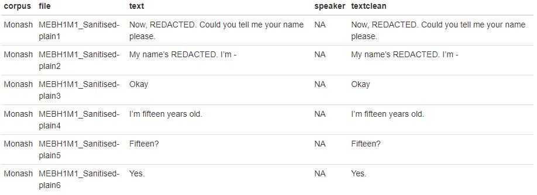

```r
vmon <- sapply(fmon, function(x){
  x <- readLines(x, encoding = "UTF-8")
  x <- x[x != ""]
  x <- paste0(x, collapse = "qwertz") %>%
  stringr::str_remove_all("qwertz    ") %>%
  stringr::str_split("qwertz") %>%
  unlist() %>%
  stringr::str_squish()
  })
# unlist
montext <- unlist(vmon)
# collapse into df
mondf <- data.frame(names(montext), names(montext), montext) %>%
  dplyr::rename(corpus = colnames(.)[1],
                file = colnames(.)[2],
                text = colnames(.)[3]) %>%
  dplyr::mutate(corpus = stringr::str_replace_all(corpus, ".*data/(.*?)/.*", "\\1"),
                file = stringr::str_replace_all(file, ".*Text/(.*?).txt", "\\1"),
                speaker = paste0("NA"),
                textclean = stringr::str_squish(text))
rownames(mondf) <- NULL
# inspect
knitr::kable(head(mondf))
```

### Load LAT

We continue with the content of the files of the *The La Trobe Corpus of Spoken Australian English* (lat)

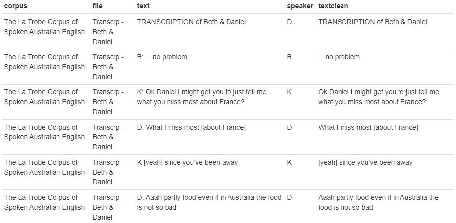

```r
vlat <- sapply(flat, function(x){
  x <- readLines(x, encoding = "UTF-8")
  x <- x[x != ""]
  })
lattext <- unlist(vlat)
# collapse into df
latdf <- data.frame(names(lattext), names(lattext),lattext) %>%
  dplyr::rename(corpus = colnames(.)[1],
                file = colnames(.)[2],
                text = colnames(.)[3]) %>%
  dplyr::mutate(corpus = stringr::str_replace_all(corpus, ".*data/(.*?)/.*", "\\1"),
                file = stringr::str_replace_all(file, ".*Raw/(.*?)-raw.*", "\\1"),
                speaker = stringr::str_remove_all(text, ":.*"),
                speaker = stringr::str_remove_all(speaker, "\\W.*\\W"),
                speaker = stringr::str_remove_all(speaker, "[^[:alpha:]]"),
                speaker = stringr::str_remove_all(speaker, "[a-z]"),
                textclean = stringr::str_remove_all(text, "^[A-Z]{1,}:{0,1}"),
                textclean = stringr::str_squish(textclean))
rownames(latdf) <- NULL
# inspect
knitr::kable(head(latdf))
```

## Collapse data into one table

We now combine the corpora into a single data frame called *oz*.

```r
oz <- rbind(artdf, gridf, mondf, latdf)
# inspect
knitr::kable(head(oz))
```

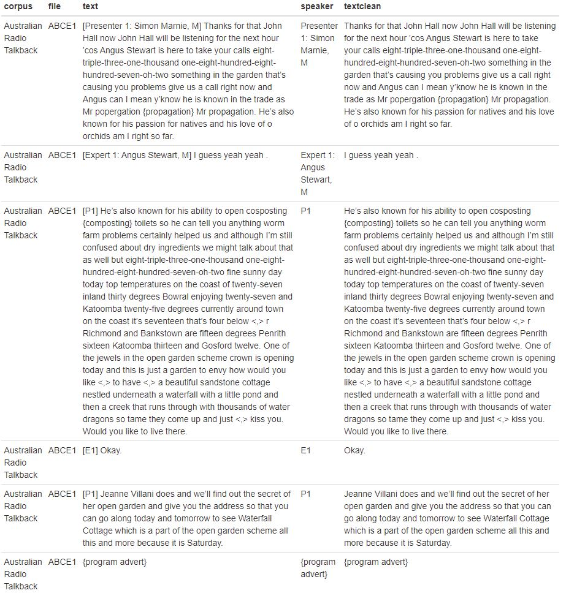

## Extract UF-or

In a next step, we extract utterances with utterance final *or*. We determine this by checking if a string (utterance) ends with the sequence *or* but we allow for another words to come after the or if it has up to three chacraters (e.g., “… or uhm?”).

```r
ufor <- oz %>%
  dplyr::mutate(ufor = ifelse(stringr::str_detect(textclean, " or {0,}.{0,3}$"), 1, 0)) %>%
  dplyr::filter(ufor == 1)
# inspect
knitr::kable(head(ufor$textclean))
```

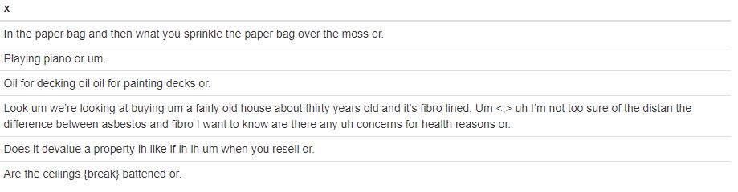

Next, we want to extract concordances (keywords-in-context) of potential hits (utterance-final *or*). The context should be two utterances preceding the utterance with utterance-final *or* and two utterances following the instance of utterance-final *or*.

```r
inds = which(stringr::str_detect(oz$textclean, " or {0,}.{0,3}$"))
# We use lapply() to get all rows for all indices, result is a list
rows <- lapply(inds, function(x) (x-2):(x+2))
# With unlist() you get all relevant rows
ufors <- oz[unlist(rows),]
# insepct
knitr::kable(head(ufors, 10))
```

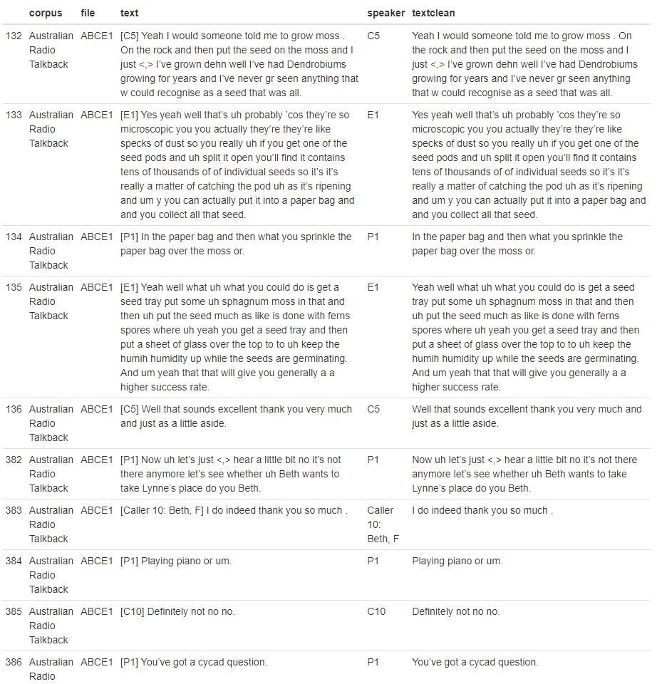

We now generate a table with the instances of utterance-final *or* and the preceding as well as subsequent utterances and save the data to out computer for the manual annotation of the functions of utterance-final *or*.

```r
# label instances
nhits <- sapply(rows, function(x){ length(x) })
nints <- 1:length(rows)
labs <- rep(paste0("instance ", nints), each = nhits)
# label context
contlabs <- rep(c("pre2", "pre1", "hit", "post1", "post2"), length(rows))
# add to kwics
ufors <- ufors %>%
  dplyr::mutate(hit = labs,
                context = contlabs) %>%
  dplyr::select(-speaker, -textclean) %>%
  dplyr::relocate(corpus, file, hit, context, text)
```

The data frame now contains five lines for each instance: *pre2*, *pre1*, *hit*, *post1*, and *post2*. The instance of utterance-final *or* is shown in the row labeled as *hit*. The table below shows the first 10 lines of the data frame (i.e., 2 instances of utterance-final *or* plus two utterances before the instance, labelled *pre2* and *pre1*, and two utterances after the instance of utterance-final *or*, labelled *post1* and *post2*).

```r
# inspect
knitr::kable(head(ufors, 10))
```

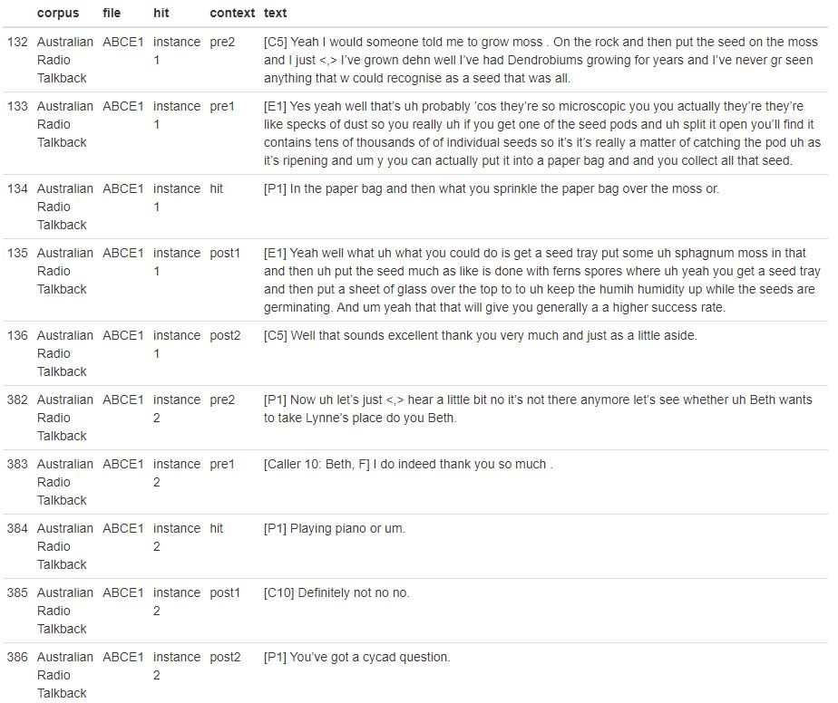

# Save data to disc for manual annotation

We now save the data so that we can annotate and code the data manually in a spreadsheet software (MS Excel).

```r
# save
write.xlsx(ufors, here::here("tables", "step1_ufor_complete.xlsx"), sheetName = "Sheet1",
           colNames = TRUE,
           rowNames = TRUE,
           append = FALSE)
```

# Step 2: Manual annotation

This section details the annotation scheme used to manually annotate the instances of UF-or in a spreadsheet software (MS Excel).

Manual annotation focused on:

1. action format (Question or Assertion)
2. question type (polar, alternative, Q-word), and
3. identification of false positives (FP)

**UF-or data annotation scheme**

The annotation scheme used to code individual instances of utterance-final *or* is provided below. Each instance was inspected and annotated with regard to the categories shown below.

| Action format | Question type | Response polarity | Response elaboration | Response alignment |  |
| --- | --- | --- | --- | --- | --- |
| Question [Q] | Information-seeking question [Q] | Yes [Y] | Explicit (yes/no, direct repeat) [E] | Type-conforming (yes/no; A or B) [TC] |  |
| Assertion [A] | Polar question [P] | No [N] | Not explicit [NE] | Non-type-conforming [NTC] |  |
|  | Alternative question [A] | Yes-No [Y-N] |  |  |  |
|  | False positive (i.e. not a question) [FP] | B-answer [B] |  |  |  |
|  |  | No Answer [NoA] |  |  |  |

# INTERACTIVE CODE BELOW

> **THE CODE CHUNKS BELOW ARE INTERACTIVE (EXECUTABLE)** WHICH ALLOWS YOU TO INSPECT THE DATA AND PROBE IT IN GREATER DETAIL.

# Data Exploration and Analysis

We now load the manually annotated data and check what the data looks like.

```r
ufor_step2 <- openxlsx::read.xlsx(here::here("tables", "step2_ufors_qa_annotated.xlsx"), sheet = 1)
# inspect
ufor_step2 %>%
  dplyr::filter(corpus == "The La Trobe Corpus of Spoken Australian English") %>%
  # show first 10 rows
  head(10) %>%
  # show results as a table
  knitr::kable()
```

| X1 | corpus | file | hit | context | text | action.format | question.type |
| --- | --- | --- | --- | --- | --- | --- | --- |
| 22687 | The La Trobe Corpus of Spoken Australian English | Transcrp - Beth & Daniel | instance 81 | pre2 | ’cos of to avoid trouble or to avoid um you know like conflict or something (?) | NA | NA |
| 22688 | The La Trobe Corpus of Spoken Australian English | Transcrp - Beth & Daniel | instance 81 | pre1 | K: mmm | NA | NA |
| 22689 | The La Trobe Corpus of Spoken Australian English | Transcrp - Beth & Daniel | instance 81 | hit | B: but I’m not sure I don’t know if that’s um general or not | A | FP |
| 22690 | The La Trobe Corpus of Spoken Australian English | Transcrp - Beth & Daniel | instance 81 | post1 | D: I think you you should have and you must have an opinion you should have your own opinion which is crazy um I tends to | NA | NA |
| 22691 | The La Trobe Corpus of Spoken Australian English | Transcrp - Beth & Daniel | instance 81 | post2 | express myself yeah and perhaps in a way it’s easier for me for example in English in English country ’cos I can do it and | NA | NA |
| 22756 | The La Trobe Corpus of Spoken Australian English | Transcrp - Beth & Daniel | instance 82 | pre2 | um but it’s not necessarily always bad to be opinionated you could use it when it’s not not being so negative | NA | NA |
| 22757 | The La Trobe Corpus of Spoken Australian English | Transcrp - Beth & Daniel | instance 82 | pre1 | D: but it does it mean having a strong opinion on everything or have just opinion on everything which is different .. no? | NA | NA |
| 22758 | The La Trobe Corpus of Spoken Australian English | Transcrp - Beth & Daniel | instance 82 | hit | B: ha.. having a strong opinion or = | Q | FP |
| 22759 | The La Trobe Corpus of Spoken Australian English | Transcrp - Beth & Daniel | instance 82 | post1 | D: = yeah [fighting] | NA | NA |
| 22760 | The La Trobe Corpus of Spoken Australian English | Transcrp - Beth & Daniel | instance 82 | post2 | B: [or just an opin..] | NA | NA |

The table has the following columns:

- X1: an identifier value allowing us to unambiguously identifying every row in the data.
- corpus: the name of the corpus in which the potential instance occurred
- file: the file in which the potential instance occurred
- hit: the number of the potential instance
- context: specification of whether the text shows previous utterances (pre2 and pre1), the instance itself (hit), or subsequent utterances (post1 and post2)
- text: the utterance preceding, containing, or following a potential instance of UF-or
- action.format: Question or Assertion
- question.type: Polar, Alternative, Q-word

Most of the cells are empty and do not contain any annotation information (these are all cells containing *NA* which stands for *not applicable*).

We continue by cleaning the data, for example, by replacing `NA` and renaming columns and variable levels to be easier to understand

```r
ufor_step2_clean <- ufor_step2 %>%
  dplyr::group_by(hit) %>%
  tidyr::fill(action.format, .direction = "updown") %>%
  tidyr::fill(question.type, .direction = "updown") %>%
  # rename
  dplyr::rename(`Action Format` = action.format,
                `Question Type` = question.type) %>%
  # renaming levels
  dplyr::mutate(`Action Format` = factor(`Action Format`,
                                       levels = c("Q", "A"),
                                       labels = c("Question (interrogative)", "Assertion (declarative)")),
                `Question Type`  = factor(`Question Type`,
                                       levels = c("P", "A", "Q", "FP"),
                                       labels = c("Polar question", "Alternative question", "Q-word question", "False positive"))) %>%
  # remove grouping
  dplyr::ungroup()
# inspect
head(ufor_step2_clean, 5)
```

```
## # A tibble: 5 × 8
##   X1    corpus                    file  hit        context text  Actio…¹ Quest…²
##   <chr> <chr>                     <chr> <chr>      <chr>   <chr> <fct>   <fct>
## 1 132   Australian Radio Talkback ABCE1 instance 1 pre2    [C5]… Questi… Polar …
## 2 133   Australian Radio Talkback ABCE1 instance 1 pre1    [E1]… Questi… Polar …
## 3 134   Australian Radio Talkback ABCE1 instance 1 hit     [P1]… Questi… Polar …
## 4 135   Australian Radio Talkback ABCE1 instance 1 post1   [E1]… Questi… Polar …
## 5 136   Australian Radio Talkback ABCE1 instance 1 post2   [C5]… Questi… Polar …
## # … with abbreviated variable names ¹`Action Format`, ²`Question Type`
```

We now create a first overview table showing how many instances there are per Action Format.

```r
ufor_step2_clean %>%
    dplyr::filter(context == "hit") %>%
  dplyr::mutate(`Question Type` = ifelse(`Question Type` == "False positive", "False positive", "N")) %>%
  dplyr::group_by(`Action Format`,`Question Type`) %>%
  dplyr::summarise(N = n()) %>%
  tidyr::spread(`Question Type`, N) %>%
  dplyr::mutate(N = N + `False positive`) %>%
  dplyr::relocate(`False positive`, .after = N) %>%
  replace(is.na(.), 0)
```

```
## # A tibble: 2 × 3
## # Groups:   Action Format [2]
##   `Action Format`              N `False positive`
##   <fct>                    <int>            <int>
## 1 Question (interrogative)    73               10
## 2 Assertion (declarative)      0               25
```

Candidate UF-or information seeking questions (N=63: 73-10)

```r
ufor_step2_clean %>%
  dplyr::filter(context == "hit") %>%
  dplyr::filter(`Question Type` != "False positive") %>%
  dplyr::group_by(`Question Type`) %>%
  dplyr::summarise(N = n()) %>%
  dplyr::add_row(`Question Type` = "Total",
                 N = sum(.$N))
```

```
## # A tibble: 4 × 2
##   `Question Type`          N
##   <chr>                <int>
## 1 Polar question          55
## 2 Alternative question     7
## 3 Q-word question          1
## 4 Total                   63
```

## False positives

All false positives combined.

```r
ufor_step2_clean %>%
  dplyr::filter(context == "hit") %>%
  dplyr::filter(`Question Type` == "False positive") %>%
  dplyr::group_by(`Question Type`) %>%
  dplyr::summarise(N = n())
```

```
## # A tibble: 1 × 2
##   `Question Type`     N
##   <fct>           <int>
## 1 False positive     35
```

**1. Assertions (N=25)**

As we were interested in UF-or questions, assertions were by definition false positives (although an interesting phenomenon in its own right).

For example *Suggestion/advice marked with UF-or* (N=1)

ART: COME3 (instance 13):

```r
ufor_step2_clean %>%
  dplyr::filter(hit == "instance 13") %>%
  dplyr::filter(context == "hit"| context == "post1") %>%
  dplyr::mutate(text = stringr::str_remove_all(text, ".*>. ")) %>%
  dplyr::select(text)
```

```
## # A tibble: 2 × 1
##   text
##   <chr>
## 1 If the vomiting is still there on Monday morning it certainly is worth a trip…
## 2 [C12] I can't have Bonox because it's two high in salt for the Meniere's.
```

**2. Interrogatives (N=10)**

1. FP due to question being request for permission rather than request for information (N=1)

ART: COME3 (instance 16)

```r
ufor_step2_clean %>%
  dplyr::filter(hit == "instance 16") %>%
  dplyr::filter(context != "post2") %>%
  dplyr::select(text)
```

```
## # A tibble: 4 × 1
##   text
##   <chr>
## 1 [C14] Yes. And I was just gunna ask about um how he and I are compatible.
## 2 [P2] I've only got a minute to the news I don't think I can add all that up.
## 3 [C14] Oh okay <P2 but I could do> well anything <P2 I could> about him or.
## 4 [P2] Yes I I can j I can do that for you okay uh five and nine's fourteen's f…
```

2. FP due to instance being utterance-medial rather than utterance-final (N=3)

MCE: MECG1M1 (instance 54)

```r
ufor_step2_clean %>%
  dplyr::filter(hit == "instance 54") %>%
  dplyr::select(text)
```

```
## # A tibble: 5 × 1
##   text
##   <chr>
## 1 Well, say you've done something wrong, you
## 2 Yeap.
## 3 And you have been punished by your uh parents or
## 4 Yeap.
## 5 by the school.
```

LTCE: Beth & Daniel (instance 82)

```r
ufor_step2_clean %>%
  dplyr::filter(hit == "instance 82") %>%
  dplyr::select(text)
```

```
## # A tibble: 5 × 1
##   text
##   <chr>
## 1 "      um but it’s not necessarily always bad to be opinionated you could use…
## 2 "D:    but it does it mean having a strong opinion on everything or have just…
## 3 "B:    ha.. having a strong opinion or ="
## 4 "D:                             = yeah [fighting]"
## 5 "B:                                  [or just an opin..]"
```

MCE: MESJ3F1 (instance 73):

```r
ufor_step2_clean %>%
  dplyr::filter(hit == "instance 73") %>%
  dplyr::select(text)
```

```
## # A tibble: 5 × 1
##   text
##   <chr>
## 1 Um, we’ve talked about, oh, have you ever been in hospital yourself?
## 2 As in like, can you just
## 3 Have you ever had an accident or
## 4 (?)
## 5 or have you been in hospital or you thought you were going to
```

3. FP created through script (N=6), i.e.:
- *or not* (instance 42, 76, 92)
- *or no* (instance 78)
- *or so* (instance 22)
- *or two* (instance 41)

*or not*

```r
ufor_step2_clean %>%
  dplyr::filter(`Question Type` == "False positive",
                context == "hit") %>%
  dplyr::filter(hit == "instance 42" | hit == "instance 76" | hit == "instance 92") %>%
  dplyr::select(text)
```

```
## # A tibble: 3 × 1
##   text
##   <chr>
## 1 J: [do you] wa↑nt breakfast or 157. no↓t= 158.
## 2 yeh I know so you wanna see whether they do or not
## 3 Ken:  That’s the same as um … tolerant isn’t it? or not
```

*or no*

```r
ufor_step2_clean %>%
  dplyr::filter(`Question Type` == "False positive",
                context == "hit") %>%
  dplyr::filter(hit == "instance 78") %>%
  dplyr::select(text)
```

```
## # A tibble: 1 × 1
##   text
##   <chr>
## 1 RB: I think the intonation was bad. Can I say it again? or no?
```

*or so*

```r
ufor_step2_clean %>%
  dplyr::filter(`Question Type` == "False positive",
                context == "hit") %>%
  dplyr::filter(hit == "instance 22") %>%
  dplyr::mutate(text = stringr::str_remove_all(text, ".*away. ")) %>%
  dplyr::select(text)
```

```
## # A tibble: 1 × 1
##   text
##   <chr>
## 1 Um do you see it going up much in the future or s just plugging away as it ha…
```

*or two*

```r
ufor_step2_clean %>%
  dplyr::filter(`Question Type` == "False positive",
                context == "hit") %>%
  dplyr::filter(hit == "instance 41") %>%
  dplyr::mutate(text = stringr::str_remove_all(text, ".* 19 ")) %>%
  dplyr::select(text)
```

```
## # A tibble: 1 × 1
##   text
##   <chr>
## 1 how many weeks after: hers is yours? >one week? 20 or two 21 (1.0) 22
```

**False negative (N=1)**

(identified by Haugh 2011 in GCSAusE, but not extracted through script) (GCSAusE011)

T: =so is it? (.) is it easy? o:r [like what]  
B: [ it’s ha: ]rd,

# Step 3: Manual annotation

This section focuses on polar interrogatives.

Responses to UF-or polar interrogatives were manually annotated by analyst (bottom-up [data-driven] and top-down [previous studies] annotation schema) (n=55)

Manual annotation focused on:

1. response **polarity** (confirming [Y], disconfirming [N], (dis)confirming [Y-N], non-answers [NA])
2. response **alignment** (type-conforming [TC], non-type-conforming [NTC])
3. response **elaboration** (elaboration [E], no elaboration [NE])

We now load the manually annotated data and check what the data looks like.

```r
ufor_step3 <- openxlsx::read.xlsx(here::here("tables", "step3_ufors_qp_annotated.xlsx"), sheet = 1)
# inspect
ufor_step3 %>%
  dplyr::filter(corpus == "The La Trobe Corpus of Spoken Australian English") %>%
  # show first 10 rows
  head(10) %>%
  # show results as a table
  knitr::kable()
```

| X1 | corpus | file | hit | context | text | action.format | question.type | response.polarity | response.elaboration | response.alignment |
| --- | --- | --- | --- | --- | --- | --- | --- | --- | --- | --- |
| 23027 | The La Trobe Corpus of Spoken Australian English | Transcrp - Heather & Marie | instance 83 | hit | think about a certain situation and you really .. hadn’t .. come to a conclusion would you say “maybe maybe yes maybe no” or… | Q | P | NA | NA | NA |
| 23028 | The La Trobe Corpus of Spoken Australian English | Transcrp - Heather & Marie | instance 83 | post1 | Marie: yeah well you have to ask me a question when I can answer yes or no well I have to answer yes or no so that I answer | NA | NA | YN | E | NTC |
| 23029 | The La Trobe Corpus of Spoken Australian English | Transcrp - Heather & Marie | instance 83 | post2 | “peut-être bien que oui, peut-être bien que non” = | NA | NA | NA | NA | NA |
| 23026 | The La Trobe Corpus of Spoken Australian English | Transcrp - Heather & Marie | instance 83 | pre1 | Heather: it when you weren’t sure .. about something about your it’s .. I sit here well what did you | NA | NA | NA | NA | NA |
| 23025 | The La Trobe Corpus of Spoken Australian English | Transcrp - Heather & Marie | instance 83 | pre2 | Marie: [yeah it’s] | NA | NA | NA | NA | NA |
| 25769 | The La Trobe Corpus of Spoken Australian English | Transcrp - Natalie & Ken | instance 96 | hit | Kerry: What makes you say that the Europeans would be … like what ex.. ..is that through experience? or .. | Q | P | NA | NA | NA |
| 25770 | The La Trobe Corpus of Spoken Australian English | Transcrp - Natalie & Ken | instance 96 | post1 | Natalie: [um] | NA | NA | NoA | NE | NTC |
| 25771 | The La Trobe Corpus of Spoken Australian English | Transcrp - Natalie & Ken | instance 96 | post2 | Kerry: [do] you know someone or it’s just a general impression you have? | NA | NA | NA | NA | NA |
| 25768 | The La Trobe Corpus of Spoken Australian English | Transcrp - Natalie & Ken | instance 96 | pre1 | Natalie: but um … | NA | NA | NA | NA | NA |
| 25767 | The La Trobe Corpus of Spoken Australian English | Transcrp - Natalie & Ken | instance 96 | pre2 | Ken: = yeah | NA | NA | NA | NA | NA |

The table has the following columns:

- X1: an identifier value allowing us to unambiguously identifying every row in the data.
- corpus: the name of the corpus in which the potential instance occurred
- file: the file in which the potential instance occurred
- hit: the number of the potential instance
- context: specification of whether the text shows previous utterances (pre2 and pre1), the instance itself (hit), or subsequent utterances (post1 and post2)
- text: the utterance preceding, containing, or following a potential instance of UF-or
- action.format: Question or Assertion
- question.type: Polar, Alternative, Q-word
- response.polarity: Polarity of the response (post1) -confirming [Y], disconfirming [N], (dis)confirming [Y-N], non-answers [NA]
- response.elaboration: Elaboration of the response (post1) - elaboration [E], no elaboration [NE]
- response.alignment: Alignment of the response (post1) - type-conforming [TC], non-type-conforming [NTC]

Most of the cells are empty and do not contain any annotation information (these are all cells containing *NA* which stands for *not applicable*).

We continue by cleaning the data, for example, by replacing `NA` and renaming columns and variable levels to be easier to understand

```r
ufor_step3_clean <- ufor_step3 %>%
  dplyr::mutate(question.type = str_squish(question.type)) %>%
  dplyr::group_by(hit) %>%
  tidyr::fill(action.format, .direction = "updown") %>%
  tidyr::fill(question.type, .direction = "updown") %>%
  tidyr::fill(response.polarity, .direction = "updown") %>%
  tidyr::fill(response.alignment, .direction = "updown") %>%
  tidyr::fill(response.elaboration, .direction = "updown") %>%
  # rename
  dplyr::rename(`Action Format` = action.format,
                `Question Type` = question.type,
                `Response Polarity` = response.polarity,
                `Response Alignment` = response.alignment,
                `Response Elaboration` = response.elaboration) %>%
  # renaming levels
  dplyr::mutate(`Action Format` = factor(`Action Format`,
                                       levels = c("Q", "A"),
                                       labels = c("Question (interrogative)", "Assertion (declarative)")),
                `Question Type`  = factor(`Question Type`,
                                       levels = c("P", "A", "Q", "FP"),
                                       labels = c("Polar question", "Alternative question", "Q-word question", "False positive")),
                `Response Polarity`  = factor(`Response Polarity`,
                                       levels = c("Y", "N", "YN", "B", "NoA"),
                                       labels = c("Confirming [Y]", "Disconfirming [N]", "(Dis)confirming [Y-N]", "B-answer [B]", "Non-answers [NA]")),
                `Response Alignment`  = factor(`Response Alignment`,
                                       levels = c("TC", "NTC"),
                                       labels = c("Type-Conforming [TC]", "Non-Type-Conforming [NTC]")),
                `Response Elaboration`  = factor(`Response Elaboration`,
                                       levels = c("E", "NE"),
                                       labels = c("Elaboration [E]", "No elaboration [NE]"))) %>%
  # remove grouping
  dplyr::ungroup()
# inspect
head(ufor_step3_clean, 5)
```

```
## # A tibble: 5 × 11
##   X1    corpus file  hit   context text  Actio…¹ Quest…² Respo…³ Respo…⁴ Respo…⁵
##   <chr> <chr>  <chr> <chr> <chr>   <chr> <fct>   <fct>   <fct>   <fct>   <fct>
## 1 134   Austr… ABCE1 inst… hit     [P1]… Questi… Polar … Confir… Elabor… Type-C…
## 2 135   Austr… ABCE1 inst… post1   [E1]… Questi… Polar … Confir… Elabor… Type-C…
## 3 136   Austr… ABCE1 inst… post2   [C5]… Questi… Polar … Confir… Elabor… Type-C…
## 4 133   Austr… ABCE1 inst… pre1    [E1]… Questi… Polar … Confir… Elabor… Type-C…
## 5 132   Austr… ABCE1 inst… pre2    [C5]… Questi… Polar … Confir… Elabor… Type-C…
## # … with abbreviated variable names ¹`Action Format`, ²`Question Type`,
## #   ³`Response Polarity`, ⁴`Response Elaboration`, ⁵`Response Alignment`
```

We now generate an overview tables.

## Response Polarity

```r
ufor_step3_clean %>%
    dplyr::filter(context == "hit") %>%
  dplyr::mutate(`Response Polarity` = dplyr::case_when(`Response Polarity` == "B-answer [B]" ~ "Non-polar",
                                                       `Response Polarity` == "Non-answers [NA]" ~ "Non-polar",
                                                       T ~ `Response Polarity`)) %>%
  dplyr::group_by(`Response Polarity`) %>%
  dplyr::summarise(N = n()) %>%
  dplyr::ungroup() %>%
  dplyr::mutate(Total = sum(N)) %>%
  dplyr::rowwise() %>%
  dplyr::mutate(Percent = round(N/Total*100, 1)) %>%
  dplyr::select(-Total) %>%
  dplyr::add_row(`Response Polarity` = "Total",
                 N = sum(.$N),
                 Percent = sum(.$Percent)) %>%
  knitr::kable()
```

| Response Polarity | N | Percent |
| --- | --- | --- |
| (Dis)confirming [Y-N] | 4 | 7.3 |
| Confirming [Y] | 25 | 45.5 |
| Disconfirming [N] | 19 | 34.5 |
| Non-polar | 7 | 12.7 |
| Total | 55 | 100.0 |

```r
ufor_step3_clean %>%
    dplyr::filter(context == "hit") %>%
  dplyr::mutate(`Response Polarity` = dplyr::case_when(`Response Polarity` == "B-answer [B]" ~ "B-answer [B]",
                                                       `Response Polarity` == "Non-answers [NA]" ~ "Non-answers [NA]",
                                                       T ~ "Polar")) %>%
  dplyr::group_by(`Response Polarity`) %>%
  dplyr::summarise(N = n()) %>%
  dplyr::ungroup() %>%
  dplyr::mutate(Total = sum(N)) %>%
  dplyr::rowwise() %>%
  dplyr::mutate(Percent = round(N/Total*100, 1)) %>%
  dplyr::select(-Total) %>%
  dplyr::add_row(`Response Polarity` = "Total",
                 N = sum(.$N),
                 Percent = sum(.$Percent)) %>%
  knitr::kable()
```

| Response Polarity | N | Percent |
| --- | --- | --- |
| B-answer [B] | 2 | 3.6 |
| Non-answers [NA] | 5 | 9.1 |
| Polar | 48 | 87.3 |
| Total | 55 | 100.0 |

```r
ufor_step3_clean %>%
    dplyr::filter(context == "hit") %>%
  dplyr::mutate(`Response Polarity` = dplyr::case_when(`Response Polarity` == "B-answer [B]" ~ "Non-polar",
                                                       `Response Polarity` == "Non-answers [NA]" ~ "Non-polar",
                                                       T ~ "Polar")) %>%
  dplyr::group_by(`Response Polarity`) %>%
  dplyr::summarise(N = n()) %>%
  dplyr::arrange(-N) %>%
  dplyr::ungroup() %>%
  dplyr::mutate(Total = sum(N)) %>%
  dplyr::rowwise() %>%
  dplyr::mutate(Percent = round(N/Total*100, 1)) %>%
  dplyr::select(-Total) %>%
  dplyr::add_row(`Response Polarity` = "Total",
                 N = sum(.$N),
                 Percent = sum(.$Percent)) %>%
  knitr::kable()
```

| Response Polarity | N | Percent |
| --- | --- | --- |
| Polar | 48 | 87.3 |
| Non-polar | 7 | 12.7 |
| Total | 55 | 100.0 |

## Elaboration

```r
ufor_step3_clean %>%
    dplyr::filter(context == "hit") %>%
  dplyr::mutate(`Response Polarity` = dplyr::case_when(`Response Polarity` == "B-answer [B]" ~ "Non-polar",
                                                       `Response Polarity` == "Non-answers [NA]" ~ "Non-polar",
                                                       T ~ "Polar")) %>%
  dplyr::filter(`Response Polarity` == "Polar") %>%
  dplyr::group_by(`Response Elaboration`) %>%
  dplyr::summarise(N = n()) %>%
  dplyr::arrange(-N) %>%
  dplyr::ungroup() %>%
  dplyr::mutate(Total = sum(N)) %>%
  dplyr::rowwise() %>%
  dplyr::mutate(Percent = round(N/Total*100, 1)) %>%
  dplyr::select(-Total) %>%
  dplyr::add_row(`Response Elaboration` = "Total",
                 N = sum(.$N),
                 Percent = sum(.$Percent)) %>%
  knitr::kable()
```

| Response Elaboration | N | Percent |
| --- | --- | --- |
| Elaboration [E] | 36 | 75 |
| No elaboration [NE] | 12 | 25 |
| Total | 48 | 100 |

## Response Alignment

```r
ufor_step3_clean %>%
  dplyr::filter(context == "hit") %>%
  group_by(`Response Alignment`) %>%
  dplyr::summarise(N = n()) %>%
  dplyr::arrange(-N) %>%
  dplyr::ungroup() %>%
  dplyr::mutate(Total = sum(N)) %>%
  dplyr::rowwise() %>%
  dplyr::mutate(Percent = round(N/Total*100, 1)) %>%
  dplyr::select(-Total) %>%
  dplyr::add_row(`Response Alignment` = "Total",
                 N = sum(.$N),
                 Percent = sum(.$Percent)) %>%
  knitr::kable()
```

| Response Alignment | N | Percent |
| --- | --- | --- |
| Type-Conforming [TC] | 32 | 58.2 |
| Non-Type-Conforming [NTC] | 23 | 41.8 |
| Total | 55 | 100.0 |

```r
ufor_step3_clean %>%
  dplyr::filter(context == "hit",
                `Response Alignment` == "Type-Conforming [TC]") %>%
  dplyr::mutate(`Response Polarity` = dplyr::case_when(`Response Polarity` == "Confirming [Y]" ~ "Confirming [Y]",
                                                       `Response Polarity` == "Disconfirming [N]" ~ "Disconfirming [N]",
                                                       TRUE ~ "other")) %>%
  group_by(`Response Alignment`, `Response Polarity`) %>%
  dplyr::summarise(Frequency = n()) %>%
  dplyr::arrange(-Frequency) %>%
  tidyr::spread(`Response Alignment`, Frequency) %>%
  replace(is.na(.), 0) %>%
  knitr::kable()
```

| Response Polarity | Type-Conforming [TC] |
| --- | --- |
| Confirming [Y] | 18 |
| Disconfirming [N] | 14 |

```r
ufor_step3_clean %>%
  dplyr::filter(context == "hit",
                `Response Alignment` == "Non-Type-Conforming [NTC]") %>%
  dplyr::mutate(`Response Polarity` = dplyr::case_when(`Response Polarity` == "Confirming [Y]" ~ "Confirming [Y]",
                                                       `Response Polarity` == "Disconfirming [N]" ~ "Disconfirming [N]",
                                                       `Response Polarity` == "(Dis)confirming [Y-N]" ~ "(Dis)confirming [Y-N]",
                                                       TRUE ~ "Non-polar")) %>%
  group_by(`Response Alignment`, `Response Polarity`) %>%
  dplyr::summarise(Frequency = n()) %>%
  dplyr::arrange(-Frequency) %>%
  tidyr::spread(`Response Alignment`, Frequency) %>%
  replace(is.na(.), 0) %>%
  dplyr::ungroup() %>%
  dplyr::mutate(Total = sum(`Non-Type-Conforming [NTC]`)) %>%
  dplyr::rowwise() %>%
  dplyr::mutate(Percent = round(`Non-Type-Conforming [NTC]`/Total*100, 1)) %>%
  dplyr::select(-Total) %>%
  dplyr::add_row(`Response Polarity` = "Total",
                 `Non-Type-Conforming [NTC]` = sum(.$`Non-Type-Conforming [NTC]`),
                 Percent = sum(.$Percent)) %>%
  knitr::kable()
```

| Response Polarity | Non-Type-Conforming [NTC] | Percent |
| --- | --- | --- |
| (Dis)confirming [Y-N] | 4 | 17.4 |
| Confirming [Y] | 7 | 30.4 |
| Disconfirming [N] | 5 | 21.7 |
| Non-polar | 7 | 30.4 |
| Total | 23 | 99.9 |

```r
ufor_step3_clean %>%
  dplyr::filter(context == "hit",
                `Response Alignment` == "Non-Type-Conforming [NTC]") %>%
  dplyr::mutate(`Response Polarity` = dplyr::case_when(`Response Polarity` == "Confirming [Y]" ~ "Polar",
                                                       `Response Polarity` == "Disconfirming [N]" ~ "Polar",
                                                       `Response Polarity` == "(Dis)confirming [Y-N]" ~ "Polar",
                                                       TRUE ~ "Non-polar")) %>%
  group_by(`Response Alignment`, `Response Polarity`) %>%
  dplyr::summarise(Frequency = n()) %>%
  dplyr::arrange(-Frequency) %>%
  tidyr::spread(`Response Alignment`, Frequency) %>%
  replace(is.na(.), 0) %>%
  dplyr::ungroup() %>%
  dplyr::mutate(Total = sum(`Non-Type-Conforming [NTC]`)) %>%
  dplyr::rowwise() %>%
  dplyr::mutate(Percent = round(`Non-Type-Conforming [NTC]`/Total*100, 1)) %>%
  dplyr::select(-Total) %>%
  dplyr::add_row(`Response Polarity` = "Total",
                 `Non-Type-Conforming [NTC]` = sum(.$`Non-Type-Conforming [NTC]`),
                 Percent = sum(.$Percent)) %>%
  knitr::kable()
```

| Response Polarity | Non-Type-Conforming [NTC] | Percent |
| --- | --- | --- |
| Non-polar | 7 | 30.4 |
| Polar | 16 | 69.6 |
| Total | 23 | 100.0 |

# Step 4: Computational-interpretive analysis

Computationally analysed responses to UF-or information-seeking polar questions [Q-P] using pivot tables and manual close-reading (N=55)

1. UF-or information seeking questions are invariably responded as polar questions
2. UF-or makes elaboration a relevant next

## 1. UF-or information seeking questions are invariably responded as polar questions

Hypothesis: UF-or information-seeking questions are invariably responded to as polar questions (i.e. p or not?) rather than alternative questions (i.e. p or q?) (cf. Haugh 2011)

**a. Distributional evidence**

48/55 responses are confirming/disconfirming/(dis)confirming (i.e. respond to as polar Q) (87.3%)

2/55 responses are q responses (i.e. respond to as alternative Q) (3.6%)

**b. Interpretive evidence**

Alternative answers are used as vehicles for teasing or repair (N=2):

1. (MCE: MEBH2FB, instance 50)

```r
ufor_step2_clean %>%
  dplyr::filter(hit == "instance 50") %>%
  dplyr::filter(context != "pre2") %>%
  dplyr::select(text)
```

```
## # A tibble: 4 × 1
##   text
##   <chr>
## 1 BH2F: you can’t smoke in here
## 2 BH2M: says who? what’re you gonna do kick me out or
## 3 BH2F: I’m gonna jump on ya
## 4 BH2F: nah I’m gonna jump on you
```

> q response to deliver counter-tease information-seeking question as vehicle for teasing challenge
2. (MCE: MECG2M1, instance 61)

```r
ufor_step2_clean %>%
  dplyr::filter(hit == "instance 61") %>%
  dplyr::filter(context != "pre2") %>%
  dplyr::select(text)
```

```
## # A tibble: 4 × 1
##   text
##   <chr>
## 1 Mmm. Finally, how would you describe Melbourne to a visitor from interstate?
## 2 Um, I think it's great. Um, what do you mean, like tell them where to go or?
## 3 Anything.
## 4 Ah it's, I'd tell them that it's a really great place to stay because ah you …
```

> q response (confirming) post-first insert expansion of prior information-seeking (Q-word) question

1. (ART: NAT2, instance 27)

```r
ufor_step2_clean %>%
  dplyr::filter(hit == "instance 27") %>%
  dplyr::filter(context != "pre2",
                context != "pre1") %>%
  dplyr::select(text)
```

```
## # A tibble: 3 × 1
##   text
##   <chr>
## 1 [C6] <laughs> <P2 laughs> What is what I wanted to ask Tim <,> and uh relucta…
## 2 [P1] It's called good writing I think <laughs>.
## 3 [C6] <laughs> Yes indeed but <E1 oh> <inaudible> Tim feel about um Dylan Thom…
```

> non-answer response teasing Q-producer Q-producer pursues response to her question
2. (ART: ABCE2, instance 3)

```r
ufor_step2_clean %>%
  dplyr::filter(hit == "instance 3") %>%
  dplyr::filter(context != "pre2") %>%
  dplyr::select(text)
```

```
## # A tibble: 4 × 1
##   text
##   <chr>
## 1 [E2] It's a that's a <inaudible> <E1 inaudible>.
## 2 [E1] Oil for decking oil <P1 yeah> oil for painting decks <P1 yes> or.
## 3 [P1] Okay <E1 laughs>.
## 4 [C4] Okay then uh you've answered the question thanks very much Woodies.
```

> non-answer response in response to tease stand-alone ‘or’ to jokingly bait recipient
3. ART: COMNE1 (instance 18)

```r
ufor_step2_clean %>%
  dplyr::filter(hit == "instance 18") %>%
  dplyr::select(text)
```

```
## # A tibble: 5 × 1
##   text
##   <chr>
## 1 [P2] What would that be like.
## 2 [P1] Oh well if you like stage shows it'd be fantastic I'm sure.
## 3 [P2] Yeah ih be ah be able to draw something outta that is it Simba was that …
## 4 [P1] <laughs>.
## 5 [P2] Simba in that one.
```

> non-answer response information-seeking question as vehicle for tease
4. ART: COME4 (instance 14)

```r
ufor_step2_clean %>%
  dplyr::filter(hit == "instance 14") %>%
  dplyr::filter(context != "pre2") %>%
  dplyr::select(text)
```

```
## # A tibble: 4 × 1
##   text
##   <chr>
## 1 [E1] So irrespective of what else is going on in your life you've got sore ar…
## 2 [C15] Um once you spoke about a j a person with jaw pain and and I think you …
## 3 [E1] They had T M J arthritis but Cathy.
## 4 [C15] Yeah.
```

> non-answer response repair of terms of prior Q

## 2. UF-or makes elaboration a relevant next

UF-or makes elaboration a relevant next (cf. Drake 2015)

**a. Distributional evidence**

**b. Interpretive evidence: Deviant cases**

> non-production of elaboration treated as accountable absence

MCE: MEBH1MB (instance 47) [deviant case]

```r
ufor_step2_clean %>%
  dplyr::filter(hit == "instance 47") %>%
  dplyr::select(text)
```

```
## # A tibble: 5 × 1
##   text
##   <chr>
## 1 all right I suppose
## 2 that’s good
## 3 tired . still tired from last night or
## 4 yeah
## 5 had a tiring week this week?
```

> treats minimal confirmation as requiring elaboration

**c. Interpretive evidence: Borderline cases**

Bare confirmation/disconfirmation functions as “go ahead” response

ART: COMNE3 (instance 21)

```r
ufor_step2_clean %>%
  dplyr::filter(hit == "instance 21") %>%
  dplyr::filter(context != "pre2",
                context != "pre1") %>%
  dplyr::select(text)
```

```
## # A tibble: 3 × 1
##   text
##   <chr>
## 1 [E1] Yeah look there you're you're right there're very few but look these day…
## 2 [C8] Yeah yeah.
## 3 [E1] Yeah guy named Nigel Plowman and he operates <C8 ah yeah> his company's …
```

MCE: MEBH2FB (instance 49)

```r
ufor_step2_clean %>%
  dplyr::filter(hit == "instance 49") %>%
  dplyr::select(text)
```

```
## # A tibble: 5 × 1
##   text
##   <chr>
## 1 BH2M: where’re they goin’
## 2 Sound of car engine revving excessively
## 3 BH2M: are we gettin' in the cars or?
## 4 BH2F: yeah
## 5 BH2M: yeah..let’s go
```

MCE: MESJ3F1 (instance 72)

```r
ufor_step2_clean %>%
  dplyr::filter(hit == "instance 72") %>%
  dplyr::filter(context != "pre2") %>%
  dplyr::select(text)
```

```
## # A tibble: 4 × 1
##   text
##   <chr>
## 1 What sort of things do you do together?
## 2 Out of school or
## 3 No
## 4 Well at school we just sort of sit down and talk about lots of things um we u…
```

Bare confirmation occasioned by noticing of matter external to ongoing sequence

GCS: AusE32 (instance 44)

```r
ufor_step2_clean %>%
  dplyr::filter(hit == "instance 44") %>%
  dplyr::filter(context != "pre2") %>%
  dplyr::select(text)
```

```
## # A tibble: 4 × 1
##   text
##   <chr>
## 1 S: I’ll cut it 95 (1.7) 96
## 2 J: So yeah:: ya gonna drop into the u:m (1.8) you gonna drop into 97 the: ten…
## 3 S: Yeah man 100 (.) 101
## 4 J: Check [pic]that out[pic] 102 (.) 103
```

96 J: So yeah:: ya gonna drop into the u:m (1.8) you gonna drop into 97 the: tent embassy:: or:? 98 (1.4) 99 S: Yeah man 100 (.) 101 J: Check ↑that out↑

Bare disconfirmation for emphatic (repeated) rejection

> emphatic rejection treats question as inapposite

ART: COMNE4 (instance 23)

```r
ufor_step2_clean %>%
  dplyr::filter(hit == "instance 23") %>%
  dplyr::filter(context != "pre2",
                context != "pre1") %>%
  dplyr::select(text)
```

```
## # A tibble: 3 × 1
##   text
##   <chr>
## 1 [E2] Uh uh I think I might've had one of those at one stage is it um uh is it…
## 2 [P1] No no no.
## 3 [E1] No <E2 hand chopper yes I've> no you hand one.
```

ART: ABCE1 (instance 2)

```r
#ufor_step2_clean$hit[str_detect(ufor_step2_clean$text, "hear a little bit")]
ufor_step2_clean %>%
  dplyr::filter(hit == "instance 2") %>%
  dplyr::filter(context != "post2") %>%
  dplyr::select(text)
```

```
## # A tibble: 4 × 1
##   text
##   <chr>
## 1 [P1] Now uh let's just <,> hear a little bit no it's not there anymore let's …
## 2 [Caller 10: Beth, F] I do indeed thank you so much <laughs>.
## 3 [P1] Playing piano or um.
## 4 [C10] Definitely not no no.
```

# Further exploration of the data

This section provides pre-written code snippets that allow researchers to further explore the data.

## Inspecting specific instances

There are overall 98 instances of potential instances of UF-or. You can access any of these (including the respective coding) if you modify the number following the sequence `"instance "` in the code below.

```r
ufor_step2_clean %>%
  dplyr::filter(hit == "instance 2")
```

```
## # A tibble: 5 × 8
##   X1    corpus                    file  hit        context text  Actio…¹ Quest…²
##   <chr> <chr>                     <chr> <chr>      <chr>   <chr> <fct>   <fct>
## 1 382   Australian Radio Talkback ABCE1 instance 2 pre2    [P1]… Questi… Polar …
## 2 383   Australian Radio Talkback ABCE1 instance 2 pre1    [Cal… Questi… Polar …
## 3 384   Australian Radio Talkback ABCE1 instance 2 hit     [P1]… Questi… Polar …
## 4 385   Australian Radio Talkback ABCE1 instance 2 post1   [C10… Questi… Polar …
## 5 386   Australian Radio Talkback ABCE1 instance 2 post2   [P1]… Questi… Polar …
## # … with abbreviated variable names ¹`Action Format`, ²`Question Type`
```

If you want to inspect the instances and coding in the data set loaded for step 3, you simply need to change `ufor_step2_clean` to `ufor_step3_clean`.

```r
ufor_step3_clean %>%
  dplyr::filter(hit == "instance 2")
```

```
## # A tibble: 5 × 11
##   X1    corpus file  hit   context text  Actio…¹ Quest…² Respo…³ Respo…⁴ Respo…⁵
##   <chr> <chr>  <chr> <chr> <chr>   <chr> <fct>   <fct>   <fct>   <fct>   <fct>
## 1 384   Austr… ABCE1 inst… hit     [P1]… Questi… Polar … Discon… No ela… Type-C…
## 2 385   Austr… ABCE1 inst… post1   [C10… Questi… Polar … Discon… No ela… Type-C…
## 3 386   Austr… ABCE1 inst… post2   [P1]… Questi… Polar … Discon… No ela… Type-C…
## 4 383   Austr… ABCE1 inst… pre1    [Cal… Questi… Polar … Discon… No ela… Type-C…
## 5 382   Austr… ABCE1 inst… pre2    [P1]… Questi… Polar … Discon… No ela… Type-C…
## # … with abbreviated variable names ¹`Action Format`, ²`Question Type`,
## #   ³`Response Polarity`, ⁴`Response Elaboration`, ⁵`Response Alignment`
```

Tabulation can be done by filtering the row containing the instance of UF-or and then grouping and summarizing based on what you want to tabulate.

For example, if you want to inspect the number of false positives among question types, you could use the command below.

```r
ufor_step2_clean %>%
  dplyr::filter(context == "hit") %>%
  group_by(`Question Type`) %>%
  summarise(Frequency = n())
```

```
## # A tibble: 4 × 2
##   `Question Type`      Frequency
##   <fct>                    <int>
## 1 Polar question              55
## 2 Alternative question         7
## 3 Q-word question              1
## 4 False positive              35
```

Or, if you want to inspect the number of question types across , you could use the command below.

```r
ufor_step2_clean %>%
  dplyr::filter(context == "hit") %>%
  group_by(`Question Type`, `Action Format`) %>%
  summarise(Frequency = n())
```

```
## # A tibble: 5 × 3
## # Groups:   Question Type [4]
##   `Question Type`      `Action Format`          Frequency
##   <fct>                <fct>                        <int>
## 1 Polar question       Question (interrogative)        55
## 2 Alternative question Question (interrogative)         7
## 3 Q-word question      Question (interrogative)         1
## 4 False positive       Question (interrogative)        10
## 5 False positive       Assertion (declarative)         25
```